# ECL749 Ateliers R

#### Validation du modèle

Dans le cas d’un glm avec une distribution de Poisson avec une seule variable explicative catégorique, il faut surtout vérifier qu’il n’y a pas de surdispersion ou de surabondance de zéros. On peut vérifier ceci avec le package [DHARMa](https://cran.r-project.org/web/packages/DHARMa/vignettes/DHARMa.html). L’idée derrière ce package est de comparer nos observations à des observations simulées à partir du modèle. Si nos observations réelles sont très différentes des observations simulées, c’est que le modèle n’est probablement pas approprié pour nos observations et nous devrions ajuster le modèle ou ses suppositions. Par exemple, si les observations simulées contiennent peu de zéros et si nos observations contiennent beaucoup de zéros, il y a probablement un problème de surabondance de zéros dans les observations et le modèle devrait être réajusté pour prendre en compte cette surabondance.

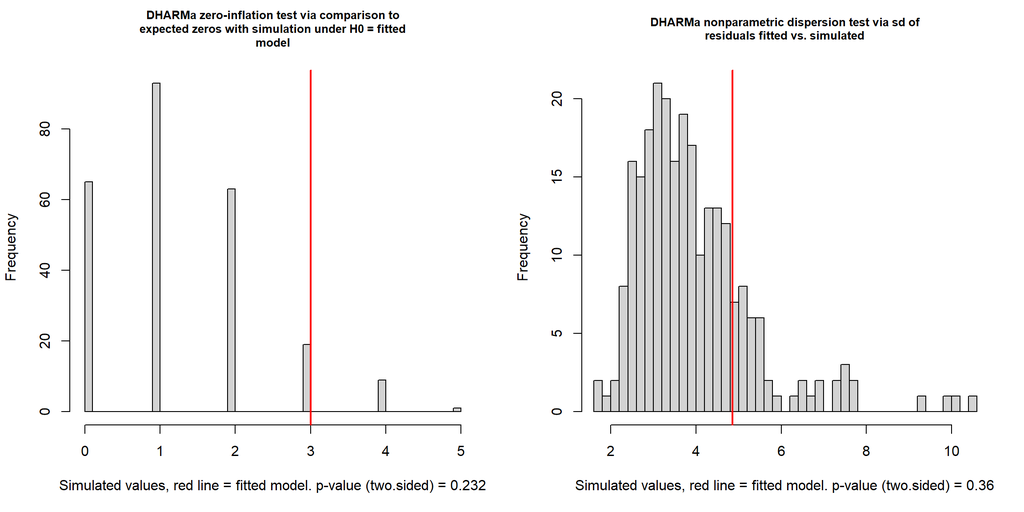

```
##
##  DHARMa zero-inflation test via comparison to expected zeros with
##  simulation under H0 = fitted model
##
## data:  simulationOutput
## ratioObsSim = 2.3659, p-value = 0.232
## alternative hypothesis: two.sided
##
##
##  DHARMa nonparametric dispersion test via sd of residuals fitted vs.
##  simulated
##
## data:  simulationOutput
## ratioObsSim = 1.2322, p-value = 0.36
## alternative hypothesis: two.sided
```

```r
library(DHARMa)
sims <- simulateResiduals(m)
par(mfrow = c(1, 2))
testZeroInflation(sims)
testDispersion(sims)
```

Dans les deux graphiques précédents, les histogrammes montrent les différentes valeurs simulées et les lignes rouges montrent les valeurs observées. Dans le premier graphique, ce sont les nombres de zéros simulés et dans le second, ce sont les écarts-types des résidus simulés. Il faut voir les deux histogrammes comme des distributions (simulées) auxquelles on compare nos observations afin de déterminer si elles sont “extrêmes” ou inatttendues par rapport aux valeurs simulées. Dans les deux cas, les valeurs observées ne diffèrent pas de façon importante des valeurs simulées. On conclut donc que le modèle est approprié pour nos données.

On peut également utiliser un graphique quantile-quantile ou les résidus quantiles afin de vérifier si notre modèle est approrié.

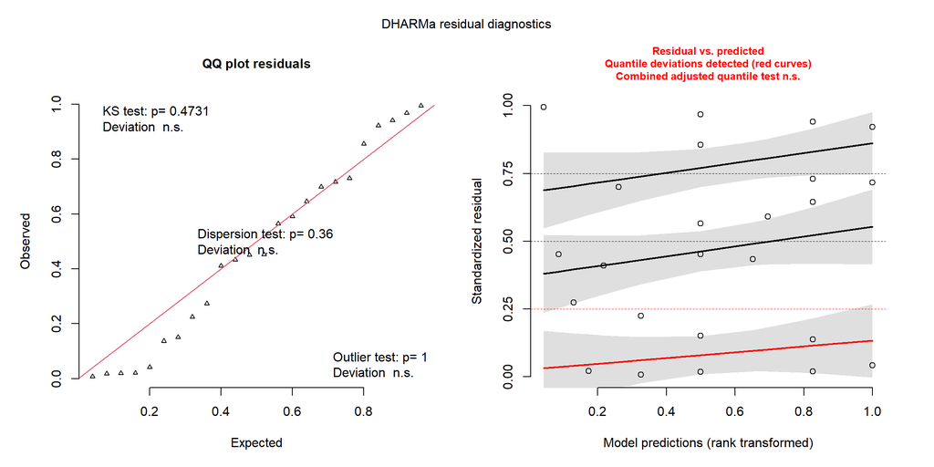

```r
plot(sims)
```

Dans le premier graphique, les points devraient être relativement bien alignés le long de la droite si notre modèle est approprié. Dans le second, nous devrions avoir des points distribués de façon uniforme dans le graphique. Nous avons relativement peu de points pour juger de cela, mais la distribution des points semble relativement uniforme. Encore ici, on conclut que note modèle est approrié.

#### Visualisation des résultats

Maintenant que nous avons valider notre modèle en vérifiant les suppositions de bases, on peut maintenant procéder à la visualisation des résultats. Pour ce faire, nous allons utiliser le package [ggeffects](https://strengejacke.github.io/ggeffects/index.html) et sa fonction `ggpredict`. À noter que je fixe le nombre de jour à 1 afin de faire les prédictions sur le nombre de prédateurs vus par jour. Aussi, j’ajoute les observations brutes sur le graphique pour fin de visualisation. Puisque les observations sont faites sur des périodes plus ou moins grandes (et donc pas sur une période de 1 jour!), je divise le nombre de prédateurs par le nombre de jours d’observation.

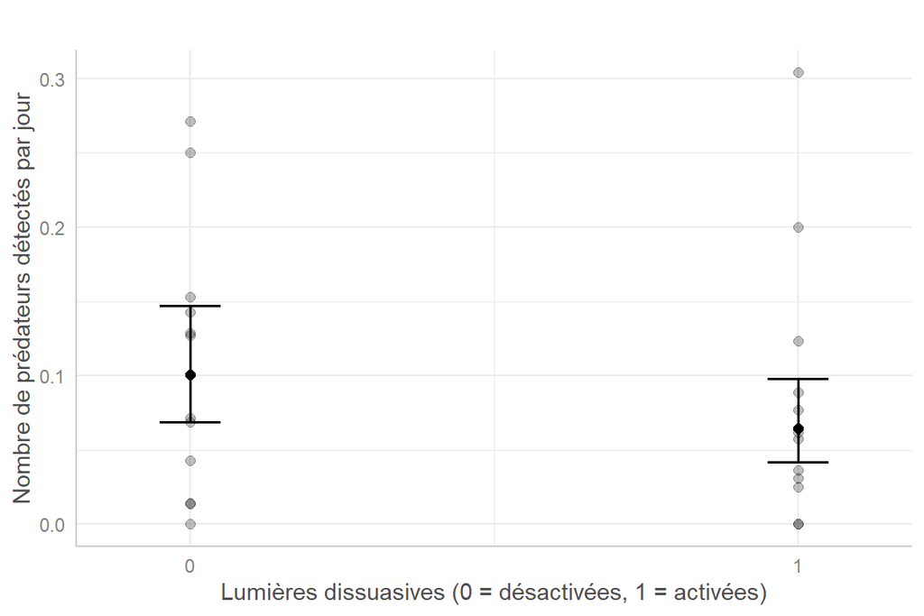

```r
library(ggeffects)
library(ggplot2)

g <- ggpredict(m, terms = c("lumiere"), condition = list(nbjour = 1))
plot(g) + geom_point(data = d, aes(x = as.integer(lumiere) - 1, y = nbpred/nbjour),
    size = 2, alpha = 0.25) + labs(x = "Lumières dissuasives (0 = désactivées, 1 = activées)",
    y = "Nombre de prédateurs détectés par jour", title = "")
```

#### Quoi présenter ?

Voici ce que je présenterais dans les sections méthodes et résultats pour cette analyse. Évidemment, si nous avions plus de détails sur les lieux, les méthodes de terrain et le dispositif technique, il faudrait les présenter. Ici, nous nous en tenons à ce qui est présenté et disponible dans la mise en situation. Ce qui est présenté ici est un bon exemple de ce qu’il faudrait présenter dans ces sections, mais ce n’est pas un exemple absolu!

##### Méthodes

L’étude a eu lieu en Argentine entre juin et septembre 2019. Un total de 12 caméras-trappes ont été installées dans 4 champs afin de détecter la présence de prédateurs. À chaque caméra, une lumière dissuasive a été installée. Les lumières ont été activées ou désactivées pendant des périodes consécutives variant de 23 à 72 jours (moy = 57.7, sd = 15.8). Pour chaque caméra, le nombre total de visites par des prédateurs a été noté.

Le nombre de visite par les prédateurs a été modélisé en fonction de la présence ou non de lumières dissuasives. Un modèle linéaire généralisé mixte (GLMM) avec une distribution de Poisson et une fonction de lien *log* a été utilisé. Afin de prendre en compte les observations effectuées par une même caméra, la caméra a été considérée comme un effet aléatoire. En raison du faible nombre de champs et de problèmes de convergence des modèles, le champ n’a pas été considéré effet aléatoire dans les modèles. Un *offset* a été utilisé dans le modèle afin de prendre en compte le nombres de jour variable pour chaque période d’observation. La fonction `glmer` du package lme4 1.1-21 (Bates et al., 2015) a été utilisée. L’absence de surdispersion et de surabondance de zéros ont été vérifiées à l’aide du package [DHARMa](https://cran.r-project.org/web/packages/DHARMa/vignettes/DHARMa.html) 0.2.4 (Hartig, 2019) et les prédictions ont été illustrées avec le package [ggeffects](https://strengejacke.github.io/ggeffects/index.html) 0.14.2 (Lüdecke, 2018).

##### Résultats

Un total de 134 visites de prédateurs ont été enregistrées (48 visites avec les lumières activées et 86 vistes avec les lumières désactivées). Bien que l’effet demeure faible, le taux de visites par les prédateurs est plus faible lorsque les lumières dissuasives sont activées (Tableau 1, Figure 1).

**Tableau 1**. Coefficients, erreurs-types, statistiques (Z) et significativité des paramètres du modèle linéaire généralisé mixte (GLMM) utilisé pour modéliser l’effet de la présence de lumières dissuasives sur le taux de visites par les prédateurs du mouton en Argentine à l’été 2019. Une distribution de Poisson et une fonction de lien log ont été utilisées dans le modèle. Un offset a été utilisé pour prendre en compte la durée variable des périodes d’enregistrement des visites par des prédateurs.

[output not shown]

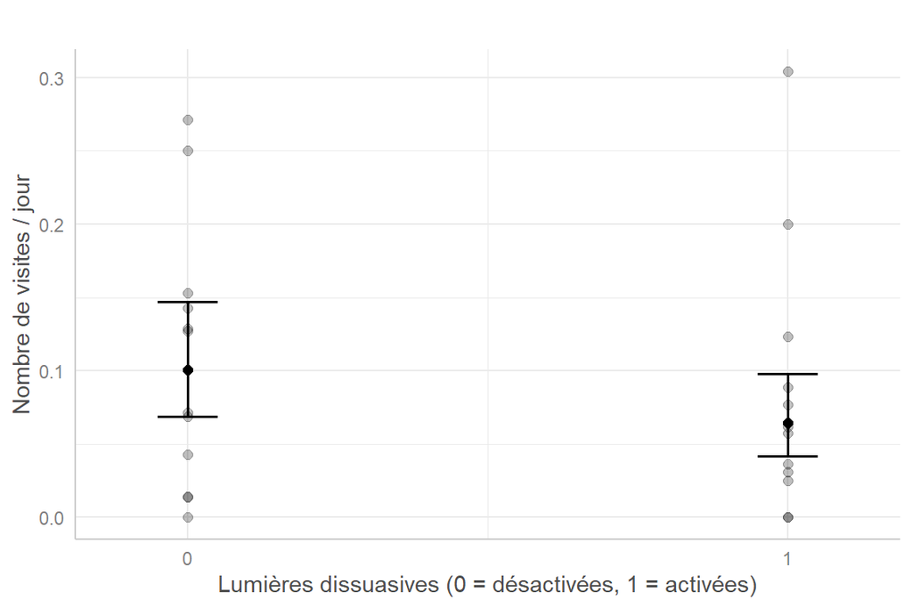

**Figure 1**. Effet de l’utilisation de lumières dissuasives sur les taux de visites par les prédateurs (nb de prédateurs / jour) aux enclos de moutons en Argentine (juin à septembre 2019). Les prédictions proviennt d’un modèle linéaire généralisé mixte avec la caméra en effet aléatoire et l’utilisation de lumières dissuasives comme facteur. Les points représentent pour chaque caméra le nombre de visites divisé par le nombre de jours d’observation. Les barres d’erreurs représentent les intervalles de confiance à 95% sur les prédictions.

## Germination de différentes espèces dans la Caatinga, Brésil.

Une des objectifs du projet consistait à déterminer quelles sont les meilleures méthodes pour favoriser la germination de différentes espèces de plantes pouvant servir à la restauration des forêts-galeries de la Caatinga. La base de données [germination](https://raw.githubusercontent.com/frousseu/ECL749/master/data/germination.csv) contient des observations sur la germination de graînes de différentes espèces de plantes en fonction de deux traitements. Le premier traitement est le type de **substrat** utilisé qui est soit du sable (S), soit du sable amendé avec une certaine quantité de fumier (A). Le deuxième traitement est la **fréquence** d’arrosage qui est soit à chaque jour (un), soit au trois jours (trois). La colonne **traitement** combine ces deux traitements en 4 possibilités (A1, A3, S1, S3). La colonne **esp** contient le nom vernaculaire de l’espèce et **germ** indique si la graîne a germé (1) ou pas (0). Ces données ont été récoltées dans la Caatinga au Brésil lors d’un stage d’une étudiante à l’été 2019.

### Solution

Voici le code que j’utiliserais pour analyser ces données. À noter qu’il y a moins de suppositions de bases à vérifier avec les glm binomiaux dont la variable réponse est binaire (*i.e.*. 0 ou 1, [voir ici](https://cran.r-project.org/web/packages/DHARMa/vignettes/DHARMa.html#binomial-01-data)). Dans ces cas, le point le plus important à vérifier est la linéarité du lien entre les variables explicatives quantitatives et la variable réponse. Dans notre cas, les variables explicatives sont toutes des facteurs et donc la question de la linéarité ne se pose pas, car une probabilité est estimée pour chaque niveau des facteurs.

```r
library(ggeffects)

d <- read.csv("https://raw.githubusercontent.com/frousseu/ECL749/master/data/germination.csv")

### modèle
m <- glm(germ ~ esp * traitement, data = d, family = binomial)
summary(m)
summary(m)$coefficients

### vérification
sims <- simulateResiduals(m)
plot(sims)
```

[output not shown]

```r
### illustration des résultats
g <- ggpredict(m, terms = c("esp", "traitement"))
plot(g) + labs(x = "Espèce", y = "Taux de germination", title = "", color = "Traitement")
```

[output not shown]

#### Quoi présenter

Voici ce que je présenterais concernant cette analyse dans les sections méthodes et résultats. Encore ici, cet exemple donne une bonne idée de quoi il faudrait présenter dans ces sections, mais ce n’est pas nécessairement un exemple absolu!

##### Méthodes

L’étude a eu lieu dans la Caatinga au Brésil en juillet 2019. Quatre traitements ont été utilisés afin de déterminer les effets du type de substrat et de la fréquence d’arrosage sur les taux de germination des graines. Deux types de substrat ont été utilisés, soit un substrat sableux (S) et un substrat sableux amendé avec du fumier (A). Deux fréquences d’arrosage ont été utilisées, soit à tous les jours (1) ou à tous les trois jours (3) pour un total de quatre traitements (S1, S3, A1 et A3). Un total de cinq espèces ont été utilisées (*calumbi*, *jamerim*, *pajeuzeiro*, *saboneteiro* et *salgueiro*) et pour chaque espèce et chaque traitement, 100 graines ont été plantées pour un total de 2000 graines.

##### Résultats

Le taux de germination global était de 53.6%. Les taux de germination diffèrent à la fois entre les espèce et entre les traitements (Tableau 1), quoique les effets du traitement sont beaucoup moins prononcés. Les taux de germination sont beaucoup plus faibles chez *pajeuzeiro* et dans une moindre mesure chez *calumbi*, alors qu’ils sont similaires chez les trois autres espèces (Figure 1). Au niveau des traitements, il n’y a aucune différence entre les traitement chez la majorité des espèces, sauf dans le cas de *jamerim* chez qui l’utilisation de sols sablonneux semblent réduire les taux de germination (Figure 1).

**Tableau 1**. Coefficients, erreurs-types, statistiques (Z) et significativité des paramètres du modèle linéaire généralisé (GLM) utilisé pour modéliser la probabilité de germination de graines de 5 espèces de plantes soumises à différents traitements (substrat sableux (S) ou amendé avec du fumier (A) et arrosage journalier (1) ou au trois jours (3). Une distribution binomiale et une fonction de lien *logit* ont été utilisées dans le modèle. Les travaux ont eu lieu en juillet 2019 dans la Caatinga, Brésil.

| Variable | Estimé | Erreur-type | Z | p |
| --- | --- | --- | --- | --- |
| (Intercept) | -0.58 | 0.21 | -2.76 | 0.006 |
| Espèce [jamerim] | 2.39 | 0.36 | 6.72 | <0.001 |
| Espèce [pajeuzeiro] | -2.01 | 0.44 | -4.53 | <0.001 |
| Espèce [saboneteiro] | 1.57 | 0.31 | 5.12 | <0.001 |
| Espèce [salgueiro] | 1.33 | 0.3 | 4.45 | <0.001 |
| Traitement [A3] | -0.13 | 0.3 | -0.45 | 0.655 |
| Traitement [S1] | 0.17 | 0.29 | 0.58 | 0.56 |
| Traitement [S3] | 0.25 | 0.29 | 0.87 | 0.385 |
| Espèce [jamerim] : Traitement [A3] | -0.17 | 0.49 | -0.34 | 0.734 |
| Espèce [pajeuzeiro] : Traitement [A3] | -0.76 | 0.77 | -0.99 | 0.323 |
| Espèce [saboneteiro] : Traitement [A3] | 0.46 | 0.45 | 1.04 | 0.3 |
| Espèce [salgueiro] : Traitement [A3] | 0.18 | 0.43 | 0.42 | 0.674 |
| Espèce [jamerim] : Traitement [S1] | -0.99 | 0.47 | -2.12 | 0.034 |
| Espèce [pajeuzeiro] : Traitement [S1] | 0.1 | 0.6 | 0.17 | 0.864 |
| Espèce [saboneteiro] : Traitement [S1] | 0.83 | 0.48 | 1.72 | 0.085 |
| Espèce [salgueiro] : Traitement [S1] | -0.35 | 0.42 | -0.83 | 0.404 |
| Espèce [jamerim] : Traitement [S3] | -1.7 | 0.46 | -3.73 | <0.001 |
| Espèce [pajeuzeiro] : Traitement [S3] | 0.14 | 0.59 | 0.23 | 0.817 |
| Espèce [saboneteiro] : Traitement [S3] | 0.08 | 0.44 | 0.18 | 0.86 |
| Espèce [salgueiro] : Traitement [S3] | -0.06 | 0.42 | -0.15 | 0.884 |

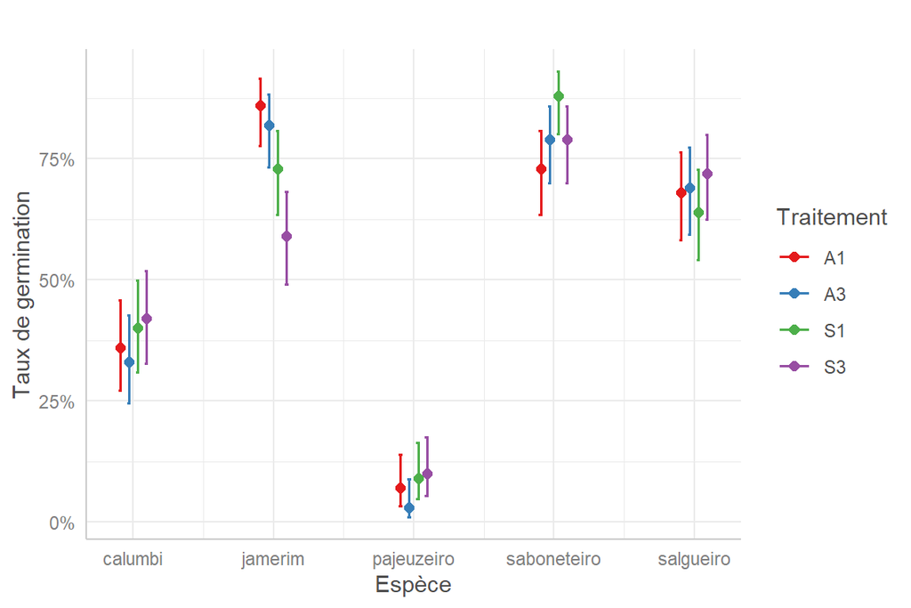

**Figure 1**. Taux de germination prédits chez différentes espèces en fonction du type de substrats et de la fréquence d’arrosage (substrat sableux (S) ou substrat sableux amendé avec du fumier (A) et arrosage journalier (1) ou aux trois jours (3)). Les tests de germination ont été réalisés au Brésil dans la Caatinga en juillet 2019. Les taux prédits proviennent d’un modèle linéaire généralisé (glm) avec une distribution binomiale et une fonction de lien *logit*. L’espèce, le traitement et leur interaction ont été considérés dans le modèle. Les barres d’erreurs représentent les intervalles de confiance à 95% sur les prédictions.

# Travail de session

Le travail de session consistera en la rédaction d’un rapport sous forme d’article scientifique pour présenter une analyse statistique d’une mise en situation proposée ou à partir de vos propres données. Pour ceux désirant utiliser leur propre jeu de données, vous devrez m’en faire part d’ici mardi le 9 mars par courriel (ou par Teams) en me montrant également la base de données qui sera utilisée (ou un extrait).

Chaque étudiant ou étudiante devra réaliser les analyses, les interpréter et présenter les résultats dans un bref rapport écrit qui prendra la forme d’un article scientifique comprenant les éléments suivants :

- **Introduction** : Courte introduction présentant et mettant en contexte la question posée et les hypothèses biologiques.
- **Méthodologie** : Description des méthodes et des données récoltées et description et justification des analyses statistiques effectuées.
- **Résultats** : Présentation des résultats accompagnée de graphiques et/ou de tableaux.
- **Discussion** : Courte explication et interprétation des résultats et de leur signification biologique.
- **Références** : Un minimum de cinq références (**articles scientifiques**) devront être utilisées pour mettre en contexte la problématique et/ou interpréter les résultats.
- **Annexe** : Code R (propre!) utilisé pour effectuer les manipulations de données, les analyses statistiques et les graphiques. Ce code devrait contenir toutes les lignes de programmation permettant de reproduire votre travail à partir de votre base de données jusqu’aux graphiques présentés. Les lignes de codes inutiles, exploratoires ou générant des erreurs devraient être éliminées. Les parties plus compliquées de votre code devraient inclure des commentaires expliquant ce qui est effectué.

Votre travail au complet devrait être de **10 pages** maximum (excluant annexe). Ce travail est à remettre au plus tard le **vendredi 26 mars à 17h**.

## Mises en situation

**1. Composition du paysage, Grand-duc d’Amérique et occurrence de la Chouette rayée**

Quelles sont les caractéristiques du paysage affectant la présence de la Chouette rayée (*i.e.* une espèce de hibou, *Strix varia*) dans le sud du Québec?

Les données ont été récoltées en Montérégie et en Estrie. À chaque site, trois stations d’écoute d’une durée de 10 minutes ont été effectuées au courant de la saison propice à la détection. L’espèce était considérée présente lorsqu’il y avait au moins une détection. Voici la base de données [chouette](https://raw.githubusercontent.com/frousseu/ECL749/master/data/chouette.csv) et une description des variables.

- **site**: station d’écoute
- **year**: année de visite
- **rayon**: rayon auquel les % ont été mesurés
- **for_feuil**: % de forêt feuillue
- **for_con**: % de forêt coniférienne
- **for_mix**: % de forêt mixte
- **for_pert**: % de forêt perturbée ou secondaire
- **cult_int**: % de culture intensive (maïs ou soya)
- **cult_ext**: % de culture extensive (pâturage, céréales, cultures maraîchères)
- **GDApres**: Grand-duc d’Amérique présent ou absent (1/0)
- **CRpres**: Chouette rayée présente ou absente (1/0)

**2. Richesse ichtyologique dans les récif coraliens**

Quelles sont les variables influençant la richesse en poissons dans les récifs coraliens?

Ces données ont été récoltées dans différentes sections de sites dans les Caraïbes. Le nombre d’espèces de poissons a été évalué à partir de 5 heures d’observations à chaque endroit dans des moments propices. Voici la base de données [poissons_coraux](https://raw.githubusercontent.com/frousseu/ECL749/master/data/poissons_coraux.csv) et une description des variables:

- **nbpoissons**: nb d’espèces de poissons détectées
- **nbcoraux**: nb d’espèces de coraux détectées
- **nbgrandscoraux**: nb d’espèces de coraux de grande taille ( > 50cm )
- **complexité**: indice de complexité du relief variant de 1 (peu complexe) à 5 (très complexe) (estimation visuelle)
- **pente**: pente générale de la section de récif échantillonnée (degrés)
- **site**: site d’échantillonnage

**3. Diversité aviaire, forêt et fragmentation en milieu tropical**

Quel est l’effet de la fragmentation forestière sur la richesse aviaire en milieu tropical?

Ces données ont été récoltées dans différents sites fragmentés d’une région du Costa Rica. Le nombre d’espèces d’oiseaux à l’intérieur de chaque fragment a été évalué en visitant chaque parcelle pour un minimum de 4h chacune et jusqu’à ce que le nb de nouvelles espèces rencontrées n’augmente pas pendant une période de deux heures. Les visites ont été effectuées pendant la période de reproduction et à des moments propices (*i.e.* tôt le matin, conditions climatiques clémentes) pour l’observation. Voici la base de données [fragmentation_aviaire](https://raw.githubusercontent.com/frousseu/ECL749/master/data/fragmentation_aviaire.csv) et une description des variables:

- **alpha**: nb d’espèces d’oiseaux répertoriées
- **alti**: altitude du site
- **super**: superficie du fragment (hectares)
- **frag**: type de fragment (*small* ou *large*)
- **foret**: % de superficie en forêt dans un rayon de 1000m
- **vieille**: % de superficie en vieille forêt dans un rayon de 1000m
- **site**: numéro du site

**4. L’abondance des moineaux dans un contexte agricole**

Quels sont les éléments du paysage affectant l’abondance du Moineau domestique (*Passer domesticus*) en milieu agricole dans le sud du Québec?

Ces données ont été récoltées à diverses fermes de la Montérégie et de l’Estrie. Des stations d’écoute d’une durée de 10 minutes ont effectuées à chaque ferme tôt le matin pendant les mois de mai et juin. Voici la base de données [moineaux](https://raw.githubusercontent.com/frousseu/ECL749/master/data/moineaux.csv) et une description des variables:

- **ferme**: identifiant de la ferme
- **vis**: numéro de la visite
- **abHOSP**: nombre de moineaux détectés
- **int500**: % de culture intensive dans un rayon de 500m (maïs ou soya)
- **ext500**: % de culture extensive dans un rayon de 500m (pâturage, céréales, cultures maraîchères)
- **for500**: % de forêt dans un rayon de 500m
- **eau500**: % d’eau (surface) dans un rayon de 500m
- **supbat500**: % de bâtiments (surface) dans un rayon de 500m
- **peribat500m**: périmètre total de bâtiments dans un rayon de 500m (en mètres)
- **perim500km**: périmètre total de bâtiments dans un rayon de 500m (en km)

**5. La diversité des papillons dans les prairies naturelles**

Quelles sont les caractéristiques de la végétation affectant la diversité en espèces de papillons dans les prairies naturelles?

Ces données ont été récoltées à divers sites dans les prairies américaines. À chaque site, 5 transects de 100 m de récolte active (avec un filet) et 2 nuitée de récolte passive (avec un drap et de la lumière) ont été effectuées pendant les mois de juin et juillet. Voici la base de données [papillons](https://raw.githubusercontent.com/frousseu/ECL749/master/data/papillons.csv) et une description des variables:

- **site**: site de récolte
- **habitat**: type d’habitat (champs de foin ou pâturage, graminées courtes, graminés grandes, mixtes)
- **batiment**: % de superficie en batiment
- **urbain**: % de superficie en zone urbaine
- **year**: année
- **julien**: jour julien
- **nbsp**: nb d’espèces de papillons

# Liens utiles

Ici, je tente de regrouper différentes ressources qui vous seront presque assurément utiles lors de la réalisation de vos projets. Si vous découvrez des éléments qui seraient pertinents à ajouter, vous pouvez m’en faire part. Afin de ne pas “noyer le poisson”, j’essaie de ne mentionner que les ressources les plus importantes.

## Ressources en ligne

### R

[Quick-R](https://www.statmethods.net/index.html): site d’introduction à R

[Base R Cheat Sheet](http://github.com/rstudio/cheatsheets/raw/master/base-r.pdf): Guide mémoire pour les fonctions de base de R

[RStudio Cheat Sheets](https://www.rstudio.com/resources/cheatsheets/): Divers guides mémoires pour R sur différents sujets

[R Spatial](http://www.rspatial.org/): Introduction à R pour l’analyse et la modélisation de données spatiales

### Statistiques

[GLMM FAQ](https://bbolker.github.io/mixedmodels-misc/glmmFAQ.html): Guide pour l’utilisation des modèles mixtes avec R

[GUSTA ME](https://sites.google.com/site/mb3gustame/): GUide to STatistical Analysis in Microbial Ecology. Un guide assez complet et très *user friendly* sur les analyses statistiques, surtout multivariées, comprenant l’explication, l’utilisation, l’interprétation, les suppositions et des exemples de plusieurs types d’analyses multivariées. Bien que le site soit orienté vers l’écologie microbienne, il est pertinent pour les biologistes et les écologistes en général.

[Analysis of community ecology data in R](https://www.davidzeleny.net/anadat-r/doku.php/en:start): Un autre site d’introduction aux analyses multivariées très utile.

[Ordination Methods for Ecologists](http://ordination.okstate.edu/): Site abordant plusieurs sujets liés à l’ordination.

[Ateliers R du CSBQ](https://qcbs.ca/wiki/r): Ateliers en ligne du CSBQ concernant plusieurs sujets liés à R (manipulation de données, programmation, ggplot) ou aux statistiques (glm, modèles mixtes, analyses multivariées, etc.)

## Ressources publiées

### Articles

[A protocol for data exploration to avoid common statistical problems](https://doi.org/10.1111/j.2041-210X.2009.00001.x)

[A protocol for conducting and presenting results of regression-type analyses](https://doi.org/10.1111/2041-210X.12577)

[Applied statistics in ecology: common pitfalls and simple solutions](https://doi.org/10.1890/ES13-00160.1)

[Generalized linear mixed models: a practical guide for ecology and evolution](https://doi.org/10.1016/j.tree.2008.10.008)

[A brief introduction to mixed effects modelling and multi-model inference in ecology](https://doi.org/10.7717/peerj.4794)

[Application of multivariate statistical techniques in microbial ecology](https://doi.org/10.1111/mec.13536)

[Multivariate analyses in microbial ecology](https://doi.org/10.1111/j.1574-6941.2007.00375.x)

### Livres

Plusieurs des livres suivants sont disponibles à la bibliothèque et certains sont disponibles en pdf sur internet.

[The R Book](https://www.wiley.com/en-us/The+R+Book%2C+2nd+Edition-p-9780470973929): Un classique très complet pour l’introduction à R et aux analyses statistiques avec R.

[Introductory statistics with R](http://www.springer.com/gp/book/9780387790534)

[Statistics for terrified biologists](https://www.wiley.com/en-us/Statistics+for+Terrified+Biologists-p-9781405149563)

[La série des *Zuur*](http://www.highstat.com/index.php/books): La série de *Highland Statistics* est très orientée sur la pratique et couvre plusieurs analyases en écologie, surtout en ce qui a trait à la modélisation (GLM, GLMM, GAM, etc.)

[Numerical Ecology with R](http://adn.biol.umontreal.ca/~numericalecology/numecolR/): Les versions anciennes sont disponibles en ligne en verison pdf.

[Numerical Ecology](https://elsevier-internet-dev.squiz.co.uk/books/numerical-ecology/legendre/978-0-444-53868-0): Un classique sur plusieurs types d’analyses en écologie, particulièrement les analyses multivariées. Les versions anciennes sont disponibles en ligne en verison pdf.

## Forums

Quelle que soit votre question sur R ou sur les statistiques, il est fort probable que celle-ci ait déjà été posée et répondue sur l’un de ces forums. Il s’agit d’utiliser les bons mots clés et de bien explorer les questions reliées.

[Stack Overflow](https://stackoverflow.com/questions/tagged/r): Programmation avec R (questions portant le tag “R”).

[Cross Validated](https://stats.stackexchange.com/): Questions concernant les statistiques.